# 2.1.2 A549 LOY vs sgCTRL — RNA-seq extended (robustness layer)

## 9.8 Y-loss confirmation (RNA + lpWGS)

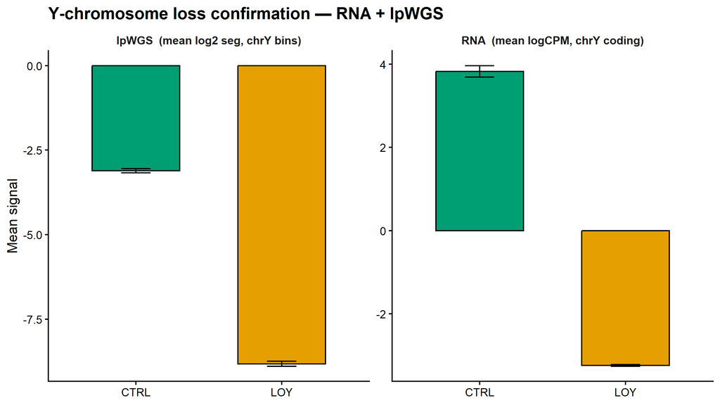

```
## Saved: y_loss_confirmation_RNA_lpWGS.(png|pdf)  [8x4.5 in]
```

## 9.9 CN-flagged DEG sensitivity rerun (by design)

Re-run Hallmark fgsea and decoupleR TF activity with `cn_driven_flag == TRUE` genes removed. Bumps in NES / TF scores that survive this filter are unlikely to be driven by autosomal CN drift. Repeated across all three DE designs — the CN flag set itself comes from the paired DE annotation in §9.4, but the upstream rank vectors differ across designs, so the sensitivity question is worth asking on each.

```
## Genes flagged CN-driven (anchor: paired DE annotation): 15
```

### Paired

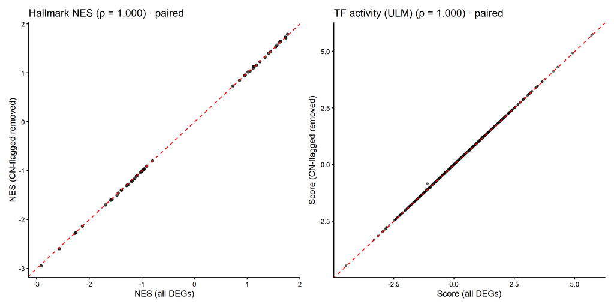

```
## Saved: cn_sensitivity_NES_TF_paired.(png|pdf)  [10x5 in]
```

### Unpaired

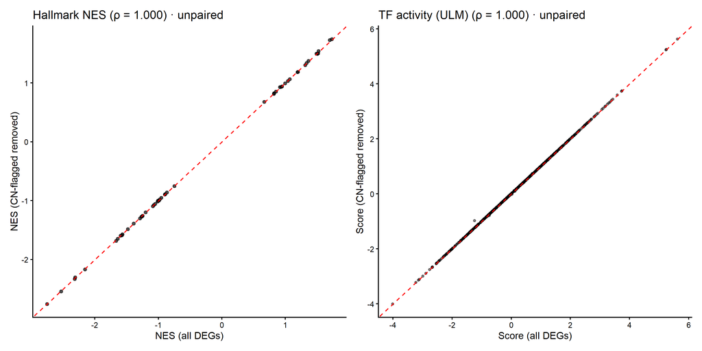

```
## Saved: cn_sensitivity_NES_TF_unpaired.(png|pdf)  [10x5 in]
```

### Pooled

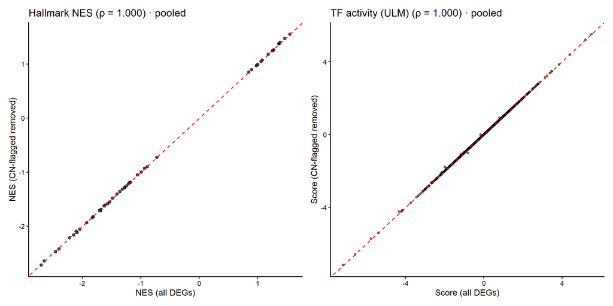

```
## Saved: cn_sensitivity_NES_TF_pooled.(png|pdf)  [10x5 in]
```

# 10. Robustness summary

Per-gene integration across the four statistical pipelines + CN flag + paralog membership. “Confident DEG” = passes ≥ 3 of {voom, voomQW, treat, edgeR-QL} at FDR<0.05 AND is not flagged CN-driven.

```
## Confident DEGs (≥3/4 frameworks, not CN-driven): 0
```

```
##   up:   0
```

```
##   down: 0
```

```
## Confident + in paralog pair: 0
```

## 10.1 Top confident DEGs

Top-40 confident DEGs

| gene_name | logFC | FDR_voom | FDR_voomQW | FDR_treat | FDR_edgeRQL | n_pass | cn_state_LOY | in_paralog_pair |
| --- | --- | --- | --- | --- | --- | --- | --- | --- |

## 10.2 Framework agreement plot

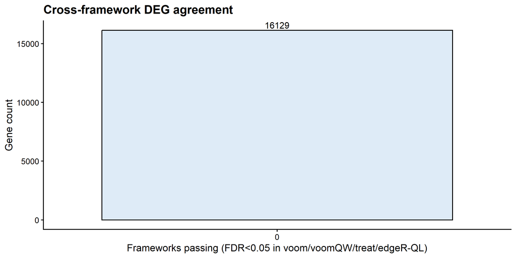

```
## Saved: robust_framework_agreement.(png|pdf)  [8x4 in]
```

## 10.3 Over-representation analysis on confident DEGs

Hypergeometric test (`fgsea::fora`) — does the confident-DEG set (≥3/4 frameworks at FDR<0.05, not CN-driven) overlap pathways more than chance? Up and down are tested separately against the same universe (all tested genes in the working DE).

```
## Universe: 16036 genes
```

```
## Confident up:   0  | down: 0
```

```
##
## === Top 15 Hallmark over-represented in Up-confident DEGs ===
```

| pathway | overlap | size | fold_enrichment | padj |
| --- | --- | --- | --- | --- |
| HALLMARK_ADIPOGENESIS | 0 | 178 | NaN | 1 |
| HALLMARK_ALLOGRAFT_REJECTION | 0 | 131 | NaN | 1 |
| HALLMARK_ANDROGEN_RESPONSE | 0 | 94 | NaN | 1 |
| HALLMARK_ANGIOGENESIS | 0 | 29 | NaN | 1 |
| HALLMARK_APICAL_JUNCTION | 0 | 174 | NaN | 1 |
| HALLMARK_APICAL_SURFACE | 0 | 39 | NaN | 1 |
| HALLMARK_APOPTOSIS | 0 | 144 | NaN | 1 |
| HALLMARK_BILE_ACID_METABOLISM | 0 | 94 | NaN | 1 |
| HALLMARK_CHOLESTEROL_HOMEOSTASIS | 0 | 72 | NaN | 1 |
| HALLMARK_COAGULATION | 0 | 107 | NaN | 1 |
| HALLMARK_COMPLEMENT | 0 | 166 | NaN | 1 |
| HALLMARK_DNA_REPAIR | 0 | 144 | NaN | 1 |
| HALLMARK_E2F_TARGETS | 0 | 195 | NaN | 1 |
| HALLMARK_EPITHELIAL_MESENCHYMAL_TRANSITION | 0 | 173 | NaN | 1 |
| HALLMARK_ESTROGEN_RESPONSE_EARLY | 0 | 186 | NaN | 1 |
| HALLMARK_ESTROGEN_RESPONSE_LATE | 0 | 176 | NaN | 1 |
| HALLMARK_FATTY_ACID_METABOLISM | 0 | 141 | NaN | 1 |
| HALLMARK_G2M_CHECKPOINT | 0 | 189 | NaN | 1 |
| HALLMARK_GLYCOLYSIS | 0 | 185 | NaN | 1 |
| HALLMARK_HEDGEHOG_SIGNALING | 0 | 33 | NaN | 1 |
| HALLMARK_HEME_METABOLISM | 0 | 167 | NaN | 1 |
| HALLMARK_HYPOXIA | 0 | 177 | NaN | 1 |
| HALLMARK_IL2_STAT5_SIGNALING | 0 | 174 | NaN | 1 |
| HALLMARK_IL6_JAK_STAT3_SIGNALING | 0 | 70 | NaN | 1 |
| HALLMARK_INFLAMMATORY_RESPONSE | 0 | 159 | NaN | 1 |
| HALLMARK_INTERFERON_ALPHA_RESPONSE | 0 | 93 | NaN | 1 |
| HALLMARK_INTERFERON_GAMMA_RESPONSE | 0 | 175 | NaN | 1 |
| HALLMARK_KRAS_SIGNALING_DN | 0 | 125 | NaN | 1 |
| HALLMARK_KRAS_SIGNALING_UP | 0 | 165 | NaN | 1 |
| HALLMARK_MITOTIC_SPINDLE | 0 | 198 | NaN | 1 |
| HALLMARK_MTORC1_SIGNALING | 0 | 193 | NaN | 1 |
| HALLMARK_MYC_TARGETS_V1 | 0 | 195 | NaN | 1 |
| HALLMARK_MYC_TARGETS_V2 | 0 | 57 | NaN | 1 |
| HALLMARK_MYOGENESIS | 0 | 159 | NaN | 1 |
| HALLMARK_NOTCH_SIGNALING | 0 | 31 | NaN | 1 |
| HALLMARK_OXIDATIVE_PHOSPHORYLATION | 0 | 185 | NaN | 1 |
| HALLMARK_P53_PATHWAY | 0 | 182 | NaN | 1 |
| HALLMARK_PANCREAS_BETA_CELLS | 0 | 23 | NaN | 1 |
| HALLMARK_PEROXISOME | 0 | 97 | NaN | 1 |
| HALLMARK_PI3K_AKT_MTOR_SIGNALING | 0 | 97 | NaN | 1 |
| HALLMARK_PROTEIN_SECRETION | 0 | 94 | NaN | 1 |
| HALLMARK_REACTIVE_OXYGEN_SPECIES_PATHWAY | 0 | 45 | NaN | 1 |
| HALLMARK_SPERMATOGENESIS | 0 | 90 | NaN | 1 |
| HALLMARK_TGF_BETA_SIGNALING | 0 | 53 | NaN | 1 |
| HALLMARK_TNFA_SIGNALING_VIA_NFKB | 0 | 188 | NaN | 1 |
| HALLMARK_UNFOLDED_PROTEIN_RESPONSE | 0 | 108 | NaN | 1 |
| HALLMARK_UV_RESPONSE_DN | 0 | 132 | NaN | 1 |
| HALLMARK_UV_RESPONSE_UP | 0 | 145 | NaN | 1 |
| HALLMARK_WNT_BETA_CATENIN_SIGNALING | 0 | 38 | NaN | 1 |
| HALLMARK_XENOBIOTIC_METABOLISM | 0 | 170 | NaN | 1 |

```
##
## === Top 15 Hallmark over-represented in Down-confident DEGs ===
```

| pathway | overlap | size | fold_enrichment | padj |
| --- | --- | --- | --- | --- |
| HALLMARK_ADIPOGENESIS | 0 | 178 | NaN | 1 |
| HALLMARK_ALLOGRAFT_REJECTION | 0 | 131 | NaN | 1 |
| HALLMARK_ANDROGEN_RESPONSE | 0 | 94 | NaN | 1 |
| HALLMARK_ANGIOGENESIS | 0 | 29 | NaN | 1 |
| HALLMARK_APICAL_JUNCTION | 0 | 174 | NaN | 1 |
| HALLMARK_APICAL_SURFACE | 0 | 39 | NaN | 1 |
| HALLMARK_APOPTOSIS | 0 | 144 | NaN | 1 |
| HALLMARK_BILE_ACID_METABOLISM | 0 | 94 | NaN | 1 |
| HALLMARK_CHOLESTEROL_HOMEOSTASIS | 0 | 72 | NaN | 1 |
| HALLMARK_COAGULATION | 0 | 107 | NaN | 1 |
| HALLMARK_COMPLEMENT | 0 | 166 | NaN | 1 |
| HALLMARK_DNA_REPAIR | 0 | 144 | NaN | 1 |
| HALLMARK_E2F_TARGETS | 0 | 195 | NaN | 1 |
| HALLMARK_EPITHELIAL_MESENCHYMAL_TRANSITION | 0 | 173 | NaN | 1 |
| HALLMARK_ESTROGEN_RESPONSE_EARLY | 0 | 186 | NaN | 1 |
| HALLMARK_ESTROGEN_RESPONSE_LATE | 0 | 176 | NaN | 1 |
| HALLMARK_FATTY_ACID_METABOLISM | 0 | 141 | NaN | 1 |
| HALLMARK_G2M_CHECKPOINT | 0 | 189 | NaN | 1 |
| HALLMARK_GLYCOLYSIS | 0 | 185 | NaN | 1 |
| HALLMARK_HEDGEHOG_SIGNALING | 0 | 33 | NaN | 1 |
| HALLMARK_HEME_METABOLISM | 0 | 167 | NaN | 1 |
| HALLMARK_HYPOXIA | 0 | 177 | NaN | 1 |
| HALLMARK_IL2_STAT5_SIGNALING | 0 | 174 | NaN | 1 |
| HALLMARK_IL6_JAK_STAT3_SIGNALING | 0 | 70 | NaN | 1 |
| HALLMARK_INFLAMMATORY_RESPONSE | 0 | 159 | NaN | 1 |
| HALLMARK_INTERFERON_ALPHA_RESPONSE | 0 | 93 | NaN | 1 |
| HALLMARK_INTERFERON_GAMMA_RESPONSE | 0 | 175 | NaN | 1 |
| HALLMARK_KRAS_SIGNALING_DN | 0 | 125 | NaN | 1 |
| HALLMARK_KRAS_SIGNALING_UP | 0 | 165 | NaN | 1 |
| HALLMARK_MITOTIC_SPINDLE | 0 | 198 | NaN | 1 |
| HALLMARK_MTORC1_SIGNALING | 0 | 193 | NaN | 1 |
| HALLMARK_MYC_TARGETS_V1 | 0 | 195 | NaN | 1 |
| HALLMARK_MYC_TARGETS_V2 | 0 | 57 | NaN | 1 |
| HALLMARK_MYOGENESIS | 0 | 159 | NaN | 1 |
| HALLMARK_NOTCH_SIGNALING | 0 | 31 | NaN | 1 |
| HALLMARK_OXIDATIVE_PHOSPHORYLATION | 0 | 185 | NaN | 1 |
| HALLMARK_P53_PATHWAY | 0 | 182 | NaN | 1 |
| HALLMARK_PANCREAS_BETA_CELLS | 0 | 23 | NaN | 1 |
| HALLMARK_PEROXISOME | 0 | 97 | NaN | 1 |
| HALLMARK_PI3K_AKT_MTOR_SIGNALING | 0 | 97 | NaN | 1 |
| HALLMARK_PROTEIN_SECRETION | 0 | 94 | NaN | 1 |
| HALLMARK_REACTIVE_OXYGEN_SPECIES_PATHWAY | 0 | 45 | NaN | 1 |
| HALLMARK_SPERMATOGENESIS | 0 | 90 | NaN | 1 |
| HALLMARK_TGF_BETA_SIGNALING | 0 | 53 | NaN | 1 |
| HALLMARK_TNFA_SIGNALING_VIA_NFKB | 0 | 188 | NaN | 1 |
| HALLMARK_UNFOLDED_PROTEIN_RESPONSE | 0 | 108 | NaN | 1 |
| HALLMARK_UV_RESPONSE_DN | 0 | 132 | NaN | 1 |
| HALLMARK_UV_RESPONSE_UP | 0 | 145 | NaN | 1 |
| HALLMARK_WNT_BETA_CATENIN_SIGNALING | 0 | 38 | NaN | 1 |
| HALLMARK_XENOBIOTIC_METABOLISM | 0 | 170 | NaN | 1 |

### Hallmark + Reactome dotplot

```
## No pathways at padj<0.1 in Hallmark/Reactome ORA.
```

### Chromatin / PRC2 ORA (CGP subset)

```
## No chromatin ORA hits at padj<0.25.
```

## 10.4 Cross-design × cross-framework panel

The §10.1–§10.3 summary above is anchored on the **paired** design (the analysis of record). This sub-section asks the broader question: across all three designs × {voom, treat, edgeR-QL}, how many of the 9 (design × framework) cells does each gene reach FDR<0.05? Genes flagged in ≥6/9 cells AND not CN-driven are the most robust LOY-driven candidates.

```
##
## Cross-design × cross-framework confident DEGs (>=6/9 cells, not CN-driven): 0
```

```
##   up:   0   down: 0
```

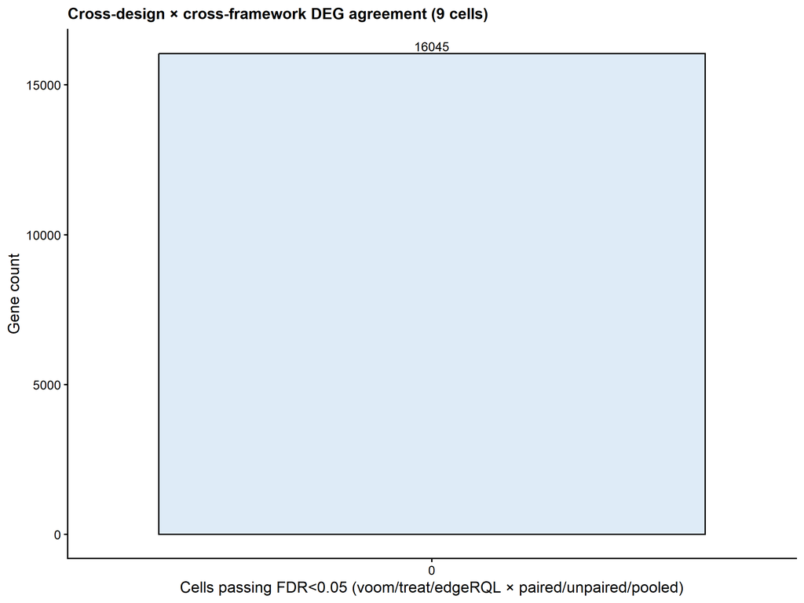

[output not shown]

### Top cross-design confident DEGs

Top-40 confident DEGs across designs (>=6/9 cells, not CN-driven)

| gene_name | logFC | n_pass9 | in_paralog_pair | cn_driven_flag | FDR_voom_paired | FDR_treat_paired | FDR_edgeRQL_paired | FDR_voom_unpaired | FDR_treat_unpaired | FDR_edgeRQL_unpaired | FDR_voom_pooled | FDR_treat_pooled | FDR_edgeRQL_pooled |
| --- | --- | --- | --- | --- | --- | --- | --- | --- | --- | --- | --- | --- | --- |

# 11. LOY transcriptomics summary table

A consolidated per-gene table of the LOY-vs-sgCTRL effect with per-sample expression. Covers:

- Every **expressed chromosome-Y gene** (post-filter), classified by genomic region as PAR1 / PAR2 / MSY (male-specific Y)
- **PAR1 / PAR2 / MSY signature** rows — mean logCPM across each region per sample, paired-LM test (treatment + passage) on the resulting scores
- **Top-20 up + top-20 down** DEGs from the paired LOY-vs-sgCTRL contrast (FDR<ALPHA, |logFC|>LFC_THR, non-chrY)
- **Genes of interest**: DCC, XIST, and the X-paralogs of each Y gene tracked in §7

Per-sample columns are logCPM (matching how the rest of the report visualises expression). Full CSV (both CPM and logCPM aggregates, per-sample logCPM) lands at `A549/DE_extended/a549_LOY_transcriptomics_summary.csv`.

## 11.1 PAR1 / PAR2 / MSY / Yp / Yq gene panel

The classifier reuses the PAR coordinate constants defined in §1.4.5 (`PAR1_X_START` etc., `Y_CENTROMERE_MID`). The §11 panel is built from `dge_full_no_yfilter$genes` so the per-sample expression matrix built in §11.2 has matching dimensions — that’s a tighter gene set than §1.4.5’s `y_panel` (which uses the unfiltered `dge0`).

```
## Expressed Y-related genes: 26  [PAR1=15, PAR2=2, MSY=9 (MSY-Yp=2, MSY-Yq=7)]
```

## 11.2 Per-sample expression helper

## 11.3 chrY gene table

PAR1 / PAR2 / MSY genes — paired DE + group-mean expression

[output not shown]

## 11.4 PAR1 / PAR2 / MSY signature scores

Y-region signatures: PAR1, PAR2, MSY + Yp/Yq arm aggregates (mean region logCPM per sample, paired LM)

| gene_name | n_genes | logFC | PValue | FDR | mean_CTRL_logCPM | mean_LOY_logCPM |
| --- | --- | --- | --- | --- | --- | --- |
| PAR1_signature | 15 | -0.599 | 0.0223 | 0.0278 | 4.54 | 3.94 |
| PAR2_signature | 2 | -0.208 | 0.4231 | 0.4231 | 2.67 | 2.46 |
| MSY_signature | 9 | -7.069 | 0.0000 | 0.0001 | 3.83 | -3.24 |
| Yp_signature | 17 | -1.204 | 0.0020 | 0.0034 | 4.52 | 3.31 |
| Yq_signature | 9 | -5.839 | 0.0001 | 0.0002 | 3.45 | -2.39 |

## 11.4b Per-sample PAR / MSY signature scores

Compact sample-by-region table — the raw per-sample data that feeds the paired-LM tests in §11.4. Each cell is the mean logCPM across the genes in that region for that sample. Useful for spotting per-sample outliers or incomplete LOY (e.g. a “LOY” sample whose MSY mean hasn’t fully collapsed) before reading the summary statistics. Restricted to the LOY-vs-sgCTRL working set (PARENTAL not included; see §1 for the rationale).

Per-sample Y-region mean logCPM (PAR1 / PAR2 / MSY / Yp / Yq)

|  | sample | treatment | passage | PAR1 | PAR2 | MSY | Yp | Yq |
| --- | --- | --- | --- | --- | --- | --- | --- | --- |
| A549-CTRL-1 | A549-CTRL-1 | CTRL | 1 | 4.74 | 2.62 | 4.10 | 4.73 | 3.65 |
| A549-CTRL-2 | A549-CTRL-2 | CTRL | 2 | 4.72 | 2.79 | 4.01 | 4.68 | 3.66 |
| A549-CTRL-3 | A549-CTRL-3 | CTRL | 3 | 4.42 | 2.39 | 3.51 | 4.39 | 3.11 |
| A549-CTRL-4 | A549-CTRL-4 | CTRL | 4 | 4.26 | 2.88 | 3.69 | 4.26 | 3.38 |
| A549-LOY-1 | A549-LOY-1 | LOY | 1 | 3.91 | 1.94 | -3.29 | 3.35 | -2.67 |
| A549-LOY-2 | A549-LOY-2 | LOY | 2 | 3.90 | 2.91 | -3.25 | 3.26 | -2.27 |
| A549-LOY-3 | A549-LOY-3 | LOY | 3 | 4.14 | 2.61 | -3.18 | 3.48 | -2.28 |
| A549-LOY-4 | A549-LOY-4 | LOY | 4 | 3.79 | 2.38 | -3.24 | 3.15 | -2.34 |

```
## Wrote 8-row sample-level PAR/MSY table to a549_LOY_sample_level_PAR_MSY.csv
```

## 11.5 Top up + top down DEGs (non-chrY)

Top 20 up + Top 20 down DEGs (paired, FDR<0.05, |logFC|>0.75, non-chrY)

| gene_name | category | logFC | FDR | mean_CTRL_logCPM | mean_LOY_logCPM |
| --- | --- | --- | --- | --- | --- |

## 11.6 Genes of interest (DCC, XIST, X-paralogs)

```
## GOI not detected post-filter: DCC, XIST, NLGN4X
```

Genes of interest (DCC, XIST, X-paralogs)

| gene_name | region | logFC | FDR | mean_CTRL_logCPM | mean_LOY_logCPM |
| --- | --- | --- | --- | --- | --- |
| DDX3X | chrX | -0.06 | 0.9999 | 8.86 | 8.79 |
| EIF1AX | chrX | -0.27 | 0.9999 | 7.05 | 6.78 |
| KDM5C | chrX | -0.04 | 0.9999 | 7.46 | 7.42 |
| KDM6A | chrX | 0.01 | 0.9999 | 4.56 | 4.58 |
| PRKX | chrX | -0.20 | 0.9999 | 5.45 | 5.25 |
| RPS4X | chrX | 0.11 | 0.9999 | 10.19 | 10.30 |
| TMSB4X | chrX | 0.17 | 0.9999 | 10.48 | 10.65 |
| USP9X | chrX | -0.06 | 0.9999 | 7.94 | 7.88 |
| ZFX | chrX | -0.07 | 0.9999 | 5.23 | 5.18 |

## 11.7 Combined export

```
## Wrote 40 rows to a549_LOY_transcriptomics_summary.csv
```